## Overview of Contribution

This R Markdown documents my individual contribution to the team project **“Exploratory Analysis of Spotify Audio Features Across Music Genres Using R.”** My primary responsibilities were:

- Locating and loading the dataset
- Performing all data cleaning and preprocessing
- Producing summary statistics and describing the dataset for the final paper
- Sharing the cleaned `spotify_df` object

## 1. Data Collection

### 1.1 Source

The dataset was obtained from Kaggle, published by user *mrmorj* (2020) under the title *“Dataset of Songs in Spotify.”* The data was originally extracted from the **Spotify Web API**, specifically the `/audio-features` endpoint, which returns quantitative audio metrics for individual tracks.

- **Citation:** mrmorj. 2020. *Dataset of Songs in Spotify*. Kaggle. https://www.kaggle.com/datasets/mrmorj/dataset-of-songs-in-spotify
- **File used:** `genres_v2.csv`
- **Access method:** Downloaded from Kaggle and loaded locally via `read.csv()`

```r
# Load required libraries
library(dplyr)
library(ggplot2)
library(tidyr)
library(knitr)

# Load the dataset
spotify_df_raw <- read.csv("genres_v2.csv", stringsAsFactors = FALSE)

# Quick peek at structure
cat("Dimensions (rows x cols):", nrow(spotify_df_raw), "x", ncol(spotify_df_raw), "\n")
```

```
## Dimensions (rows x cols): 42305 x 22
```

```r
cat("Column names:\n")
```

```
## Column names:
```

```r
print(names(spotify_df_raw))
```

```
##  [1] "danceability"     "energy"           "key"              "loudness"
##  [5] "mode"             "speechiness"      "acousticness"     "instrumentalness"
##  [9] "liveness"         "valence"          "tempo"            "type"
## [13] "id"               "uri"              "track_href"       "analysis_url"
## [17] "duration_ms"      "time_signature"   "genre"            "song_name"
## [21] "Unnamed..0"       "title"
```

## 2. Data Description (Raw)

### 2.1 Basic Properties

```r
cat("Total tracks:", nrow(spotify_df_raw), "\n")
```

```
## Total tracks: 42305
```

```r
cat("Total features (columns):", ncol(spotify_df_raw), "\n")
```

```
## Total features (columns): 22
```

```r
cat("Unique genres:", length(unique(spotify_df_raw$genre)), "\n")
```

```
## Unique genres: 15
```

```r
cat("Genres present:\n")
```

```
## Genres present:
```

```r
print(sort(unique(spotify_df_raw$genre)))
```

```
##  [1] "Dark Trap"       "dnb"             "Emo"             "hardstyle"
##  [5] "Hiphop"          "Pop"             "psytrance"       "Rap"
##  [9] "RnB"             "techhouse"       "techno"          "trance"
## [13] "trap"            "Trap Metal"      "Underground Rap"
```

### 2.2 Missing Values (Raw Dataset)

```r
missing_counts <- colSums(is.na(spotify_df_raw))
missing_df <- data.frame(
  Feature = names(missing_counts),
  Missing_Count = missing_counts,
  Missing_Pct = round(missing_counts / nrow(spotify_df_raw) * 100, 1)
)
kable(missing_df[missing_df$Missing_Count > 0, ], row.names = FALSE,
      caption = "Columns with missing values in raw dataset")
```

Columns with missing values in raw dataset

| Feature | Missing_Count | Missing_Pct |
| --- | --- | --- |
| Unnamed..0 | 21525 | 50.9 |

### 2.3 Duplicate Rows

```r
cat("Duplicate rows:", sum(duplicated(spotify_df_raw)), "\n")
```

```
## Duplicate rows: 0
```

## 3. Data Cleaning

The following steps were taken to prepare a clean `spotify_df` for team use.

### Step 1 — Retain only analytical columns

We drop administrative/metadata columns (`Unnamed: 0`, `type`, `id`, `uri`, `track_href`, `analysis_url`, `title`) that carry no analytical value. We retain `song_name` as a label even though it has many missing values, since it is not used in any computation.

```r
# Columns to keep
keep_cols <- c("danceability", "energy", "key", "loudness", "mode",
               "speechiness", "acousticness", "instrumentalness",
               "liveness", "valence", "tempo", "duration_ms",
               "time_signature", "genre", "song_name")

spotify_df <- spotify_df_raw %>%
  select(all_of(keep_cols))

cat("Columns after selection:", ncol(spotify_df), "\n")
```

```
## Columns after selection: 15
```

### Step 2 — Ensure correct data types

```r
# Numeric audio features
num_features <- c("danceability", "energy", "loudness", "speechiness",
                  "acousticness", "instrumentalness", "liveness",
                  "valence", "tempo", "duration_ms")

spotify_df <- spotify_df %>%
  mutate(across(all_of(num_features), as.numeric),
         key            = as.integer(key),
         mode           = as.factor(mode),          # 0 = minor, 1 = major
         time_signature = as.integer(time_signature),
         genre          = as.factor(genre))

cat("Data types after conversion:\n")
```

```
## Data types after conversion:
```

```r
print(sapply(spotify_df, class))
```

```
##     danceability           energy              key         loudness
##        "numeric"        "numeric"        "integer"        "numeric"
##             mode      speechiness     acousticness instrumentalness
##         "factor"        "numeric"        "numeric"        "numeric"
##         liveness          valence            tempo      duration_ms
##        "numeric"        "numeric"        "numeric"        "numeric"
##   time_signature            genre        song_name
##        "integer"         "factor"      "character"
```

### Step 3 — Remove rows with NA in core audio features

```r
before <- nrow(spotify_df)
spotify_df <- spotify_df %>%
  filter(complete.cases(select(., all_of(num_features))))
after <- nrow(spotify_df)

cat("Rows before:", before, "\n")
```

```
## Rows before: 42305
```

```r
cat("Rows after removing NA in audio features:", after, "\n")
```

```
## Rows after removing NA in audio features: 42305
```

```r
cat("Rows removed:", before - after, "\n")
```

```
## Rows removed: 0
```

### Step 4 — Remove physical outliers

Loudness values above 0 dB are physically impossible for normalized tracks; duration of 0 ms indicates a corrupt record.

```r
before <- nrow(spotify_df)
spotify_df <- spotify_df %>%
  filter(loudness <= 0,
         duration_ms > 0,
         tempo > 0)
after  <- nrow(spotify_df)

cat("Rows removed by outlier filter:", before - after, "\n")
```

```
## Rows removed by outlier filter: 210
```

```r
cat("Final cleaned dataset size:", nrow(spotify_df), "tracks\n")
```

```
## Final cleaned dataset size: 42095 tracks
```

### Step 5 — Verify final cleanliness

```r
cat("Missing values in cleaned spotify_df:\n")
```

```
## Missing values in cleaned spotify_df:
```

```r
print(colSums(is.na(spotify_df[, num_features])))
```

```
##     danceability           energy         loudness      speechiness
##                0                0                0                0
##     acousticness instrumentalness         liveness          valence
##                0                0                0                0
##            tempo      duration_ms
##                0                0
```

```r
cat("\nDuplicate rows:", sum(duplicated(spotify_df)), "\n")
```

```
##
## Duplicate rows: 4093
```

## 4. Cleaned Dataset — Summary Statistics

```r
summary_tbl <- spotify_df %>%
  select(all_of(num_features)) %>%
  summarise(across(everything(),
    list(
      mean   = ~round(mean(.),   3),
      median = ~round(median(.), 3),
      sd     = ~round(sd(.),     3),
      min    = ~round(min(.),    3),
      max    = ~round(max(.),    3)
    ),
    .names = "{.col}__{.fn}"
  )) %>%
  pivot_longer(everything(),
               names_to  = c("Feature", "Stat"),
               names_sep = "__") %>%
  pivot_wider(names_from = Stat, values_from = value)

kable(summary_tbl, caption = "Descriptive statistics for numeric audio features")
```

Descriptive statistics for numeric audio features

| Feature | mean | median | sd | min | max |
| --- | --- | --- | --- | --- | --- |
| danceability | 0.640 | 0.646 | 0.157 | 0.065 | 0.988 |
| energy | 0.762 | 0.802 | 0.184 | 0.000 | 1.000 |
| loudness | -6.501 | -6.253 | 2.905 | -33.357 | 0.000 |
| speechiness | 0.136 | 0.075 | 0.126 | 0.023 | 0.946 |
| acousticness | 0.096 | 0.016 | 0.171 | 0.000 | 0.988 |
| instrumentalness | 0.284 | 0.006 | 0.371 | 0.000 | 0.989 |
| liveness | 0.214 | 0.135 | 0.175 | 0.011 | 0.988 |
| valence | 0.357 | 0.322 | 0.233 | 0.019 | 0.988 |
| tempo | 147.451 | 144.961 | 23.875 | 57.967 | 220.290 |
| duration_ms | 251034.766 | 224813.000 | 103099.404 | 25600.000 | 913052.000 |

### Genre Distribution

```r
genre_counts <- spotify_df %>%
  count(genre, sort = TRUE) %>%
  rename(Count = n) %>%
  mutate(Percent = round(Count / sum(Count) * 100, 1))

kable(genre_counts, caption = "Track counts per genre")
```

Track counts per genre

| genre | Count | Percent |
| --- | --- | --- |
| Underground Rap | 5862 | 13.9 |
| Dark Trap | 4573 | 10.9 |
| Hiphop | 3028 | 7.2 |
| trance | 2999 | 7.1 |
| techhouse | 2975 | 7.1 |
| psytrance | 2961 | 7.0 |
| techno | 2956 | 7.0 |
| hardstyle | 2934 | 7.0 |
| dnb | 2933 | 7.0 |
| trap | 2853 | 6.8 |
| RnB | 2098 | 5.0 |
| Trap Metal | 1934 | 4.6 |
| Rap | 1848 | 4.4 |
| Emo | 1680 | 4.0 |
| Pop | 461 | 1.1 |

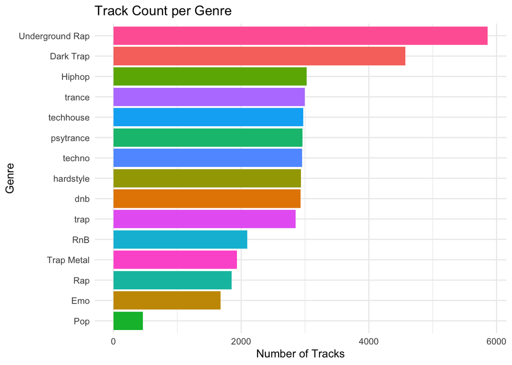

```r
ggplot(genre_counts, aes(x = reorder(genre, Count), y = Count, fill = genre)) +
  geom_col(show.legend = FALSE) +
  coord_flip() +
  labs(title = "Track Count per Genre",
       x = "Genre", y = "Number of Tracks") +
  theme_minimal()
```

## 5. Data Dictionary

```r
dict <- data.frame(
  Feature = c("danceability","energy","key","loudness","mode",
              "speechiness","acousticness","instrumentalness","liveness",
              "valence","tempo","duration_ms","time_signature","genre","song_name"),
  Type = c("Numeric (0–1)","Numeric (0–1)","Integer (0–11)","Numeric (dB)",
           "Factor (0/1)","Numeric (0–1)","Numeric (0–1)","Numeric (0–1)",
           "Numeric (0–1)","Numeric (0–1)","Numeric (BPM)","Integer (ms)",
           "Integer","Factor","Character"),
  Description = c(
    "Suitability of a track for dancing; 1.0 = most danceable",
    "Intensity and activity; 1.0 = most energetic",
    "Musical key (0 = C, 1 = C#, …, 11 = B)",
    "Overall loudness in decibels; typically –60 to 0 dB",
    "Modality: 1 = major, 0 = minor",
    "Presence of spoken words; >0.66 = likely spoken word",
    "Confidence the track is acoustic; 1.0 = acoustic",
    "Probability of no vocals; >0.5 = likely instrumental",
    "Probability of a live audience; >0.8 = likely live recording",
    "Musical positiveness; 1.0 = happy/euphoric, 0.0 = sad/angry",
    "Estimated tempo in beats per minute",
    "Track duration in milliseconds",
    "Estimated time signature (beats per bar)",
    "Spotify genre label (15 unique values)",
    "Track title from Spotify (partially missing — not used in analysis)"
  )
)
kable(dict, caption = "Data Dictionary for spotify_df")
```

Data Dictionary for spotify_df

| Feature | Type | Description |
| --- | --- | --- |
| danceability | Numeric (0–1) | Suitability of a track for dancing; 1.0 = most danceable |
| energy | Numeric (0–1) | Intensity and activity; 1.0 = most energetic |
| key | Integer (0–11) | Musical key (0 = C, 1 = C#, …, 11 = B) |
| loudness | Numeric (dB) | Overall loudness in decibels; typically –60 to 0 dB |
| mode | Factor (0/1) | Modality: 1 = major, 0 = minor |
| speechiness | Numeric (0–1) | Presence of spoken words; >0.66 = likely spoken word |
| acousticness | Numeric (0–1) | Confidence the track is acoustic; 1.0 = acoustic |
| instrumentalness | Numeric (0–1) | Probability of no vocals; >0.5 = likely instrumental |
| liveness | Numeric (0–1) | Probability of a live audience; >0.8 = likely live recording |
| valence | Numeric (0–1) | Musical positiveness; 1.0 = happy/euphoric, 0.0 = sad/angry |
| tempo | Numeric (BPM) | Estimated tempo in beats per minute |
| duration_ms | Integer (ms) | Track duration in milliseconds |
| time_signature | Integer | Estimated time signature (beats per bar) |
| genre | Factor | Spotify genre label (15 unique values) |
| song_name | Character | Track title from Spotify (partially missing — not used in analysis) |

## 6. Sharing the Cleaned Data

The cleaned `spotify_df` object is saved as an `.RData` file so all team members can load it directly without repeating the cleaning steps.

```r
# Run this once to produce the shared file
save(spotify_df, file = "spotify_df_clean.RData")

# Team members load it with:
# load("spotify_df_clean.RData")
```

## 7. Analytical Decisions & Justifications

[output not shown]